```python
import numpy as np
import pandas as pd
import matplotlib.pyplot as plt
import re

import os
import imp
```

```python
#from mes_fonctions import *
import mes_fonctions
```

# Exploration

## Chargement des Données

- On va regrouper les différents fichiers dans un même dataset
- On by-pass les informations erronées (dans le fichier 04 notamment il y a des nombres de champs non valables)
- On reindexe pour avoir un index global

```python
REP = 'datas/Dataset+Projet+4/'
l_df = []

for i in range(1,13):
    FILE_NAME = REP+'2016_{:02d}.csv'.format(i)
    #print('Récupération du fichier {}'.format(FILE_NAME))
    l_df.append(pd.read_csv(FILE_NAME, error_bad_lines=False,
                            low_memory=False, warn_bad_lines=False))

# On fabrique un unique Dataset avec toutes les valeurs
df = pd.concat(l_df)

# Suppression de la liste temporaire de noms
del l_df

# On relance l'indexation
df.reset_index(inplace=True, drop=True)
```

## Erreur de Données : Suppressions

> On constate des erreurs dans les données.
> - Une donnée de date dans la colonne d'année : '16-03-04'
>   - Nous les supprimons manuellement
> - Des données erronnées dans DEST_AIRPORT_SEQ_ID
>   - 1800-1859
>   - 0.00
> - Dans le fichier 04 des quotes supplémentaires avaient été ajoutés
>   - Nous passons sur les différentes features pour les caster en INT si possible sinon nous les castons en FLOAT, et les laissons en STRING si cela ne fonctionne pas (ps: les colonnes ayant des valeurs nan sont des FLOAT)

```python
# Suppression de la ligne ayant une date à la place d'une ANNEE
df.drop(index=df[df['YEAR']=='16-03-04'].index, axis=0, inplace=True)

# Suppression des lignes ayant des données erronées dans DEST_AIRPORT_SEQ_ID
df.drop(index=df[df['DEST_AIRPORT_SEQ_ID']=='1800-1859'].index, axis=0, inplace=True)
df.drop(index=df[df['DEST_AIRPORT_SEQ_ID']=='0.00'].index, axis=0, inplace=True)
```

```python
# On applique le nettoyage des quotes sur les données numériques
# (sur toutes les colonnes)
for nom_colonne in df.columns:
    mes_fonctions.nettoie_valeur_numeriques(df, col_name=nom_colonne)
```

```
--> TRANSFORMATION KO sur FL_DATE
--> TRANSFORMATION KO sur UNIQUE_CARRIER
--> TRANSFORMATION KO sur CARRIER
--> TRANSFORMATION KO sur TAIL_NUM
--> TRANSFORMATION KO sur ORIGIN
--> TRANSFORMATION KO sur ORIGIN_CITY_NAME
--> TRANSFORMATION KO sur ORIGIN_STATE_ABR
--> TRANSFORMATION KO sur ORIGIN_STATE_NM
--> TRANSFORMATION KO sur DEST
--> TRANSFORMATION KO sur DEST_CITY_NAME
--> TRANSFORMATION KO sur DEST_STATE_ABR
--> TRANSFORMATION KO sur DEST_STATE_NM
--> TRANSFORMATION KO sur DEP_TIME_BLK
--> TRANSFORMATION KO sur TAXI_OUT
--> TRANSFORMATION KO sur ARR_TIME_BLK
--> TRANSFORMATION KO sur CANCELLATION_CODE
```

## Autres suppressions:

- Nous avons une seule valeur nulle pour ARR_TIME_BLK qui de plus a une valeur TAXI_OUT erronnée '11.00.00':
  - Nous la supprimons

```python
df.drop(index=df[df.ARR_TIME_BLK.isnull()].index, axis=0, inplace=True)
```

## Coup d'oeil sur les données:

- On affiche le nombre de données uniques pour chaque colonne
- Pour les colonnes ayant moins de 15 valeurs différentes : on les affiche

```python
for i in df.columns:
    if (df[i].nunique()<=15):
        print("{} : {}".format(i,df[i].nunique()))
        print("\t\t", df[i].unique())
    else:
        print("{} : {}".format(i,df[i].nunique()))
```

```
YEAR : 1
		 [2016]
QUARTER : 4
		 [1 2 3 4]
MONTH : 12
		 [ 1  2  3  4  5  6  7  8  9 10 11 12]
DAY_OF_MONTH : 31
DAY_OF_WEEK : 7
		 [3 4 5 6 7 1 2]
FL_DATE : 366
UNIQUE_CARRIER : 12
		 ['AA' 'AS' 'B6' 'DL' 'F9' 'HA' 'NK' 'EV' 'OO' 'UA' 'VX' 'WN']
AIRLINE_ID : 12
		 [19805 19930 20409 19790 20436 19690 20416 20366 20304 19977 21171 19393]
CARRIER : 12
		 ['AA' 'AS' 'B6' 'DL' 'F9' 'HA' 'NK' 'EV' 'OO' 'UA' 'VX' 'WN']
TAIL_NUM : 5035
FL_NUM : 6974
ORIGIN_AIRPORT_ID : 313
ORIGIN_AIRPORT_SEQ_ID : 322
ORIGIN_CITY_MARKET_ID : 291
ORIGIN : 313
ORIGIN_CITY_NAME : 308
ORIGIN_STATE_ABR : 52
ORIGIN_STATE_FIPS : 52
ORIGIN_STATE_NM : 52
ORIGIN_WAC : 52
DEST_AIRPORT_ID : 310
DEST_AIRPORT_SEQ_ID : 319
DEST_CITY_MARKET_ID : 289
DEST : 310
DEST_CITY_NAME : 306
DEST_STATE_ABR : 52
DEST_STATE_FIPS : 52
DEST_STATE_NM : 52
DEST_WAC : 52
CRS_DEP_TIME : 1334
DEP_TIME : 1440
DEP_DELAY : 1337
DEP_DELAY_NEW : 1272
```

[output cut: 27 more lines]

```
FLIGHTS : 1
		 [ 1. nan]
DISTANCE : 1364
DISTANCE_GROUP : 11
		 [ 4. 10.  8.  3.  5.  7. 11.  1.  2.  9.  6. nan]
CARRIER_DELAY : 1207
WEATHER_DELAY : 688
NAS_DELAY : 608
SECURITY_DELAY : 172
LATE_AIRCRAFT_DELAY : 749
FIRST_DEP_TIME : 1293
TOTAL_ADD_GTIME : 235
LONGEST_ADD_GTIME : 202
Unnamed: 64 : 0
		 [nan]
```

# Suppression de colonnes

## Colonnes

- CARRIER et UNIQUE_CARRIER sont les mêmes données -> on supprime UNIQUE_CARRIER
- La colonne 'Unnamed: 64' est vide -> on la supprime
- La colonne 'Year' ne comporte qu'une donnée -> on la supprime

```python
df.drop(columns=['UNIQUE_CARRIER', 'YEAR', 'Unnamed: 64'], axis=1, inplace=True)
```

# Les Informations d'Aéroports

- Nous avons des informations répétées sur les données des aéroports
- Nous les mettons à part dans un autre DataSet
- Nous conservons uniquement 'ORIGIN_AIRPORT_SEQ_ID' et 'DEST_AIRPORT_SEQ_ID' comme clef entre les 2 dataSet
- Pour plus de détail voir le noteBook 'ANNEXE-4-1_Exploration_Cleaning-Details'

```python
# Conservation des données à cette étape pour l'utilisation dans 'ANNEXE-4-1_Exploration_Cleaning-Details'
df.to_csv('datas_total_etape_0.csv', index=False)
```

```python
# on regroupe les informations d'aeroport dans un même dataset
ORIGIN = df.groupby(['ORIGIN_AIRPORT_ID','ORIGIN_AIRPORT_SEQ_ID',
                     'ORIGIN_CITY_MARKET_ID', 'ORIGIN',
                     'ORIGIN_CITY_NAME',
                     'ORIGIN_STATE_ABR', 'ORIGIN_STATE_FIPS',
                     'ORIGIN_STATE_NM', 'ORIGIN_WAC']).size().reset_index(name='NB')

DEST = df.groupby(['DEST_AIRPORT_ID','DEST_AIRPORT_SEQ_ID',
                     'DEST_CITY_MARKET_ID', 'DEST',
                     'DEST_CITY_NAME',
                     'DEST_STATE_ABR', 'DEST_STATE_FIPS',
                     'DEST_STATE_NM', 'DEST_WAC']).size().reset_index(name='NB')

# On modifie les noms des colonnes
ORIGIN.columns = ['AIRPORT_ID', 'AIRPORT_SEQ_ID', 'CITY_MARKET_ID', 'CITY_CODE', 'CITY_NAME',
                  'STATE_ABR', 'STATE_FIPS', 'STATE_NM', 'WAC', 'NB']

DEST.columns = ['AIRPORT_ID', 'AIRPORT_SEQ_ID', 'CITY_MARKET_ID', 'CITY_CODE', 'CITY_NAME',
                  'STATE_ABR', 'STATE_FIPS', 'STATE_NM', 'WAC', 'NB']

# La colonne NB ne sert plus à rien :
del ORIGIN['NB']
del DEST['NB']

# On regroupe les informations dans le DataSet : AEROPORTS
AEROPORTS = ORIGIN.append(DEST).groupby(['AIRPORT_ID', 'AIRPORT_SEQ_ID', 'CITY_MARKET_ID', 'CITY_CODE', 'CITY_NAME',
                  'STATE_ABR', 'STATE_FIPS', 'STATE_NM', 'WAC']).size().reset_index(name='NB')
del AEROPORTS['NB']

# Pour le dataSet AEROPORT on met AIRPORT_SEQ_ID en index
AEROPORTS.set_index('AIRPORT_SEQ_ID', inplace=True)

# On supprime les 2 datasets temporaires
del ORIGIN
del DEST
```

```python
# Nous pouvons maintenant supprimer les données d'Aeroports
#.  que nous avons déportées dans l'autre DataSet

l_col_to_destroy = ['ORIGIN_AIRPORT_ID', 'ORIGIN_CITY_MARKET_ID', 'ORIGIN',
                   'ORIGIN_CITY_NAME', 'ORIGIN_STATE_ABR', 'ORIGIN_STATE_FIPS',
                   'ORIGIN_STATE_NM', 'ORIGIN_WAC',
                   'DEST_AIRPORT_ID', 'DEST_CITY_MARKET_ID', 'DEST',
                   'DEST_CITY_NAME', 'DEST_STATE_ABR', 'DEST_STATE_FIPS',
                   'DEST_STATE_NM', 'DEST_WAC'
                   ]

for col_name in l_col_to_destroy:
    del df[col_name]
```

Pour information:

> FL_DATE reprend les informations de YEAR / MONTH / DAY_OF_MONTH sans erreur

# Données manquantes

## Coup d'oeil sur les données vides

On parcourt les colonnes et on liste le nombre de données présentes.

Quand des données manquent on donne le nombre de données présentes / manquantes ainsi que le pourcentage de données manquantes.

```python
for col in df.columns:
    mes_fonctions.compte_nb_donnees_abs(df, col)
```

```
QUARTER -- 5635974
MONTH -- 5635974
DAY_OF_MONTH -- 5635974
DAY_OF_WEEK -- 5635974
FL_DATE -- 5635974
AIRLINE_ID -- 5635974
CARRIER -- 5635974
	-> TAIL_NUM -- 5623224 OK -- 12750 VIDES --  0 %
FL_NUM -- 5635974
ORIGIN_AIRPORT_SEQ_ID -- 5635974
DEST_AIRPORT_SEQ_ID -- 5635974
CRS_DEP_TIME -- 5635974
	-> DEP_TIME -- 5572436 OK -- 63538 VIDES --  1 %
	-> DEP_DELAY -- 5572436 OK -- 63538 VIDES --  1 %
	-> DEP_DELAY_NEW -- 5572436 OK -- 63538 VIDES --  1 %
	-> DEP_DEL15 -- 5572436 OK -- 63538 VIDES --  1 %
	-> DEP_DELAY_GROUP -- 5572436 OK -- 63538 VIDES --  1 %
DEP_TIME_BLK -- 5635974
	-> TAXI_OUT -- 5570453 OK -- 65521 VIDES --  1 %
	-> WHEELS_OFF -- 5570453 OK -- 65521 VIDES --  1 %
	-> WHEELS_ON -- 5567993 OK -- 67981 VIDES --  1 %
	-> TAXI_IN -- 5567993 OK -- 67981 VIDES --  1 %
CRS_ARR_TIME -- 5635974
	-> ARR_TIME -- 5567993 OK -- 67981 VIDES --  1 %
	-> ARR_DELAY -- 5556196 OK -- 79778 VIDES --  1 %
	-> ARR_DELAY_NEW -- 5556196 OK -- 79778 VIDES --  1 %
	-> ARR_DEL15 -- 5556196 OK -- 79778 VIDES --  1 %
	-> ARR_DELAY_GROUP -- 5556196 OK -- 79778 VIDES --  1 %
ARR_TIME_BLK -- 5635974
CANCELLED -- 5635974
			/!\ CANCELLATION_CODE -- 65974 OK -- 5570000 VIDES -- 98 %
	-> DIVERTED -- 5635973 OK -- 1 VIDES --  0 %
	-> CRS_ELAPSED_TIME -- 5635967 OK -- 7 VIDES --  0 %
	-> ACTUAL_ELAPSED_TIME -- 5556195 OK -- 79779 VIDES --  1 %
	-> AIR_TIME -- 5556195 OK -- 79779 VIDES --  1 %
	-> FLIGHTS -- 5635973 OK -- 1 VIDES --  0 %
	-> DISTANCE -- 5635973 OK -- 1 VIDES --  0 %
	-> DISTANCE_GROUP -- 5635973 OK -- 1 VIDES --  0 %
			/!\ CARRIER_DELAY -- 968440 OK -- 4667534 VIDES -- 82 %
			/!\ WEATHER_DELAY -- 968440 OK -- 4667534 VIDES -- 82 %
			/!\ NAS_DELAY -- 968440 OK -- 4667534 VIDES -- 82 %
			/!\ SECURITY_DELAY -- 968440 OK -- 4667534 VIDES -- 82 %
			/!\ LATE_AIRCRAFT_DELAY -- 968440 OK -- 4667534 VIDES -- 82 %
			/!\ FIRST_DEP_TIME -- 34533 OK -- 5601441 VIDES -- 99 %
			/!\ TOTAL_ADD_GTIME -- 34533 OK -- 5601441 VIDES -- 99 %
			/!\ LONGEST_ADD_GTIME -- 34533 OK -- 5601441 VIDES -- 99 %
```

## ARR_TIME

- Le but du projet est d'analyser les retards sur les vols.
- ARR_TIME est le retard d'arrivée : c'est donc une information essentielle
- Il est peu intéressant de conserver les données n'ayant pas cette information
- De plus le pourcentage de données ARR_TIME manquantes est faible (1.2 % pour les 67 981 lignes)
- Ces informations sont remplacées par des informations pour l'analyse de l'annulation (CANCELLED /CANCELLATION_CODE)

> Nous supprimons les lignes ayant ARR_TIME vide

```python
df.drop(index=df[df['ARR_DELAY'].isnull()].index, axis=0, inplace=True)
```

```python
# Nous regardons les données qu'il reste
for col in df.columns:
    mes_fonctions.compte_nb_donnees_abs(df, col)
```

```
QUARTER -- 5556196
MONTH -- 5556196
DAY_OF_MONTH -- 5556196
DAY_OF_WEEK -- 5556196
FL_DATE -- 5556196
AIRLINE_ID -- 5556196
CARRIER -- 5556196
TAIL_NUM -- 5556196
FL_NUM -- 5556196
ORIGIN_AIRPORT_SEQ_ID -- 5556196
DEST_AIRPORT_SEQ_ID -- 5556196
CRS_DEP_TIME -- 5556196
DEP_TIME -- 5556196
DEP_DELAY -- 5556196
DEP_DELAY_NEW -- 5556196
DEP_DEL15 -- 5556196
DEP_DELAY_GROUP -- 5556196
DEP_TIME_BLK -- 5556196
TAXI_OUT -- 5556196
WHEELS_OFF -- 5556196
WHEELS_ON -- 5556196
TAXI_IN -- 5556196
CRS_ARR_TIME -- 5556196
ARR_TIME -- 5556196
ARR_DELAY -- 5556196
ARR_DELAY_NEW -- 5556196
ARR_DEL15 -- 5556196
ARR_DELAY_GROUP -- 5556196
ARR_TIME_BLK -- 5556196
CANCELLED -- 5556196
			/!\ CANCELLATION_CODE -- 1 OK -- 5556195 VIDES -- 99 %
	-> DIVERTED -- 5556195 OK -- 1 VIDES --  0 %
	-> CRS_ELAPSED_TIME -- 5556195 OK -- 1 VIDES --  0 %
	-> ACTUAL_ELAPSED_TIME -- 5556195 OK -- 1 VIDES --  0 %
	-> AIR_TIME -- 5556195 OK -- 1 VIDES --  0 %
	-> FLIGHTS -- 5556195 OK -- 1 VIDES --  0 %
	-> DISTANCE -- 5556195 OK -- 1 VIDES --  0 %
	-> DISTANCE_GROUP -- 5556195 OK -- 1 VIDES --  0 %
			/!\ CARRIER_DELAY -- 968440 OK -- 4587756 VIDES -- 82 %
			/!\ WEATHER_DELAY -- 968440 OK -- 4587756 VIDES -- 82 %
			/!\ NAS_DELAY -- 968440 OK -- 4587756 VIDES -- 82 %
			/!\ SECURITY_DELAY -- 968440 OK -- 4587756 VIDES -- 82 %
			/!\ LATE_AIRCRAFT_DELAY -- 968440 OK -- 4587756 VIDES -- 82 %
			/!\ FIRST_DEP_TIME -- 32331 OK -- 5523865 VIDES -- 99 %
			/!\ TOTAL_ADD_GTIME -- 32331 OK -- 5523865 VIDES -- 99 %
			/!\ LONGEST_ADD_GTIME -- 32331 OK -- 5523865 VIDES -- 99 %
```

## Suite de la suppression

- Nous avons 1 seule ligne pour laquelle nous avons un code d'anulation (CANCELLATION_CODE)
  - dans le doute sur cette donnée : nous la supprimons ainsi que la colonne
- Nous pouvons aussi supprimer les features 'CANCELLED', 'DIVERTED' et 'FLIGHTS' qui ne comportent qu'une seule valeur

```python
# Suppression de la ligne ayant un code d'annulation
df.drop(index=df[df['CANCELLATION_CODE'].notnull()].index, axis=0, inplace=True)

# Suppression de la colonne de codes d'annulation
del df['CANCELLATION_CODE']

# Suppression de colonnes n'ayant plus qu'une valeur
del df['CANCELLED']
del df['DIVERTED']
del df['FLIGHTS']
```

### A noter:

> - les features 'CARRIER_DELAY', 'WEATHER_DELAY', 'NAS_DELAY', 'SECURITY_DELAY', 'LATE_AIRCRAFT_DELAY' sont toutes absentes pour les mêmes données (il faut le vérifier mais c'est bien le cas)
> - elles sont absentes quand le délai d'arrivée est inférieur à 15 minutes
> - cette information est donnée par la feature 'ARR_DEL15' : 0 pour arrivée avec moins de 15 minutes de retards (1 sinon)

# Données manquantes

- Les données 'CARRIER_DELAY', 'WEATHER_DELAY', 'NAS_DELAY','SECURITY_DELAY', 'LATE_AIRCRAFT_DELAY' ont des données manquantes
- Ces données sont manquantes si le retard à l'arrivée est inférieur à 15 minutes.
- Elles ont pour minimum 0
- Nous allons remplacer les valeurs manquantes par 0
- Nous pourrons les retrouver via la feature ARR_DEL15

```python
# Minimum de ces features
df2 = df[['CARRIER_DELAY', 'WEATHER_DELAY', 'NAS_DELAY','SECURITY_DELAY', 'LATE_AIRCRAFT_DELAY']]
df2.describe().T[['min']].T
```

|  | CARRIER_DELAY | WEATHER_DELAY | NAS_DELAY | SECURITY_DELAY | LATE_AIRCRAFT_DELAY |
| --- | --- | --- | --- | --- | --- |
| min | 0.0 | 0.0 | 0.0 | 0.0 | 0.0 |

```python
df['CARRIER_DELAY'].fillna(value=0, inplace=True)
df['WEATHER_DELAY'].fillna(value=0, inplace=True)
df['NAS_DELAY'].fillna(value=0, inplace=True)
df['SECURITY_DELAY'].fillna(value=0, inplace=True)
df['LATE_AIRCRAFT_DELAY'].fillna(value=0, inplace=True)
```

> Les informations 'FIRST_DEP_TIME' , 'TOTAL_ADD_GTIME' et 'LONGEST_ADD_GTIME' sont en nombre très faible.

> Cela n'apporte pas d'information avec si peu de données

> Nous allons les supprimer

```python
del df['FIRST_DEP_TIME']
del df['TOTAL_ADD_GTIME']
del df['LONGEST_ADD_GTIME']
```

# Analyse de Doublons

On regarde les doublons de données. On considère comme doublons des vols ayant les mêmes :

- 'FL_DATE',
- 'FL_NUM',
- 'TAIL_NUM',
- 'ORIGIN_AIRPORT_SEQ_ID',
- 'DEST_AIRPORT_SEQ_ID'
- 'CRS_DEP_TIME'

```python
u = df.groupby(['FL_DATE', 'FL_NUM', 'TAIL_NUM',
              'ORIGIN_AIRPORT_SEQ_ID',
             'CRS_DEP_TIME']).size().reset_index(name='Freq')

print('Nous avons {} doublons'.format(u[u.Freq>1].shape[0]))
print('Au maximum les lignes sont répétées {} fois'.format(u.Freq.max()))
```

```
Nous avons 116047 doublons
Au maximum les lignes sont répétées 2 fois
```

> Nous avons 116047 lignes en doublons (1 fois chacune)

> Nous allons supprimer ces lignes dont l'index est le plus grand pour chaque

```python
u = df[['FL_DATE', 'FL_NUM', 'TAIL_NUM', 'ORIGIN_AIRPORT_SEQ_ID', 'CRS_DEP_TIME']]

u = u.copy()
u.loc[:,'IDX'] = u.index.values
u.loc[:, 'NB'] = 1

u = u.groupby(['FL_DATE', 'FL_NUM', 'TAIL_NUM',
              'ORIGIN_AIRPORT_SEQ_ID',
             'CRS_DEP_TIME']).agg({'IDX':max, 'NB':'sum'})

u = u[u.NB>1]['IDX'].get_values()

df.drop(index=u, axis=1, inplace=True)
```

# SAUVEGARDE DES BDD

```python
df.to_csv('datas_total_etape_1.csv', index=False)
AEROPORTS.to_csv('aeroports_nettoyes.csv', index=True)
```

```python
#df = pd.read_csv('datas_total_etape_1.csv')
#AEROPORTS = pd.read_csv('aeroports_nettoyes.csv', index_col='AIRPORT_SEQ_ID')
```

# Feature Engineering

## Heure de Départ et d'Arrivée

- Les heures de départs et d'arrivées sont données dans des groupes catégoriels en texte DEP_TIME_BLK et ARR_TIME_BLK sous la forme '1400-1459'
- pour faciliter l'exploitation nous allons les supprimer et les remplacer par des heures sous forme d'entier.

```python
df['ARR_HOUR'] = np.round(df['CRS_ARR_TIME']/100)
df['DEP_HOUR'] = np.round(df['CRS_DEP_TIME']/100)
```

```python
df['ARR_ACT_HOUR'] = np.round(df['ARR_TIME']/100)
df['DEP_ACT_HOUR'] = np.round(df['DEP_TIME']/100)
```

```python
# Les BLK2 sont reformaté en entiers: correspondent aux mêmes ensembles
df['DEP_TIME_BLK2'] = df['DEP_TIME_BLK'].apply(lambda x: int(x[:2]))
df['ARR_TIME_BLK2'] = df['ARR_TIME_BLK'].apply(lambda x: int(x[:2]))
```

## Jours Fériés

```python
l_holiday = [
    '2016-01-01',
    '2016-01-18',
    '2016-02-15',
    '2016-04-15',
    '2016-05-08',
    '2016-05-30',
    '2016-06-19',
    '2016-07-04',
    '2016-09-05',
    '2016-10-10',
    '2016-11-11',
    '2016-11-24',
    '2016-11-25',
    '2016-12-26'
]

from datetime import datetime

tstamp_1 = datetime.strptime(datetime.now().strftime('%Y-%m-%d %H:%M:%S.%f'), '%Y-%m-%d %H:%M:%S.%f')
print("DEBUT : ", tstamp_1)

d_nb_jour = {}

for d_day in df.FL_DATE.unique()[:]:
    fmt = '%Y-%m-%d'
    tstamp1 = datetime.strptime(d_day, fmt)
    l_diff_d = []

    for d_off in l_holiday:
        tstamp2 = datetime.strptime(d_off, fmt)

        if (tstamp2 > tstamp1):
            d = tstamp2 - tstamp1
        else:
            d = tstamp1 - tstamp2

        l_diff_d.append(d.days)
    d_nb_jour[d_day] = min(l_diff_d)

tstamp_2 = datetime.strptime(datetime.now().strftime('%Y-%m-%d %H:%M:%S.%f'), '%Y-%m-%d %H:%M:%S.%f')
print("FIN1 : ", tstamp_2, '--', tstamp_2-tstamp_1)

# AJOUT DE LA FEATURE HDAYS
df['HDAYS'] = df.FL_DATE.apply(lambda x: d_nb_jour[x])

tstamp_3 = datetime.strptime(datetime.now().strftime('%Y-%m-%d %H:%M:%S.%f'), '%Y-%m-%d %H:%M:%S.%f')
print("FIN2 : ", tstamp_3, '--', tstamp_3-tstamp_2)
```

```
DEBUT :  2018-09-17 09:49:43.695948
FIN1 :  2018-09-17 09:49:43.898421 -- 0:00:00.202473
FIN2 :  2018-09-17 09:49:45.247315 -- 0:00:01.348894
```

## ACCUMULATION DES AVIONS SUR PISTE

```python
from datetime import datetime

# GENERATION DE LA NOUVELLE FEATURE
u = df.groupby(['ORIGIN_AIRPORT_SEQ_ID', 'DEP_HOUR', 'FL_DATE']).size().reset_index(name='Freq')
u = u.set_index(['ORIGIN_AIRPORT_SEQ_ID', 'DEP_HOUR', 'FL_DATE'])

u_id = u.index.get_level_values(level=0).unique().values
u_heures = u.index.get_level_values(level=1).unique().values
u_jours = u.index.get_level_values(level=2).unique().values

tstamp_1 = datetime.strptime(datetime.now().strftime('%Y-%m-%d %H:%M:%S.%f'), '%Y-%m-%d %H:%M:%S.%f')
print("DEBUT : ", tstamp_1)

d_total = {}
for h in u_heures:
    d_total[h] = {}
    for j in u_jours:
        d_total[h][j] = {}

# Dans d_total on a : d_total[heures][jour][id]
tstamp_2 = datetime.strptime(datetime.now().strftime('%Y-%m-%d %H:%M:%S.%f'), '%Y-%m-%d %H:%M:%S.%f')
print("FIN : ", tstamp_2-tstamp_1)

for i in u.index:
    d_total[i[1]][i[2]][i[0]] = u.loc[i]['Freq']

tstamp_3 = datetime.strptime(datetime.now().strftime('%Y-%m-%d %H:%M:%S.%f'), '%Y-%m-%d %H:%M:%S.%f')
print("FIN_fabrication_dictionnaire : ", tstamp_3-tstamp_2)

#DEBUT :  2018-09-03 11:14:50.774947
#FIN :  0:00:00.002151
#FIN :  0:02:10.148501

def test_get_info(row):
    m_ORIGIN_AIRPORT_SEQ_ID = row['ORIGIN_AIRPORT_SEQ_ID']
    m_DEP_HOUR = row['DEP_HOUR']
    m_FL_DATE = row['FL_DATE']
    return  d_total[m_DEP_HOUR][m_FL_DATE][m_ORIGIN_AIRPORT_SEQ_ID]

tstamp_1 = datetime.strptime(datetime.now().strftime('%Y-%m-%d %H:%M:%S.%f'), '%Y-%m-%d %H:%M:%S.%f')
print("DEBUT : ", tstamp_1)

df['DEP_NB_CUMUL_PAR_HEURE'] = df.apply(lambda row: test_get_info(row),axis=1)

tstamp_2 = datetime.strptime(datetime.now().strftime('%Y-%m-%d %H:%M:%S.%f'), '%Y-%m-%d %H:%M:%S.%f')
print("FIN_Ajout_colonne : ", tstamp_2, '--', tstamp_2-tstamp_1)
```

```
DEBUT :  2018-09-17 09:49:47.021222
FIN :  0:00:00.001865
FIN_fabrication_dictionnaire :  0:02:18.979637
DEBUT :  2018-09-17 09:52:06.002951
FIN_Ajout_colonne :  2018-09-17 09:54:35.990420 -- 0:02:29.987469
```

```python
# GENERATION DE LA NOUVELLE FEATURE
u = df.groupby(['DEST_AIRPORT_SEQ_ID', 'ARR_HOUR', 'FL_DATE']).size().reset_index(name='Freq')
u = u.set_index(['DEST_AIRPORT_SEQ_ID', 'ARR_HOUR', 'FL_DATE'])

u_id = u.index.get_level_values(level=0).unique().values
u_heures = u.index.get_level_values(level=1).unique().values
u_jours = u.index.get_level_values(level=2).unique().values

tstamp_1 = datetime.strptime(datetime.now().strftime('%Y-%m-%d %H:%M:%S.%f'), '%Y-%m-%d %H:%M:%S.%f')
print("DEBUT : ", tstamp_1)

d_total = {}
for h in u_heures:
    d_total[h] = {}
    for j in u_jours:
        d_total[h][j] = {}

# Dans d_total on a : d_total[heures][jour][id]
tstamp_2 = datetime.strptime(datetime.now().strftime('%Y-%m-%d %H:%M:%S.%f'), '%Y-%m-%d %H:%M:%S.%f')
print("FIN : ", tstamp_2-tstamp_1)

for i in u.index:
    d_total[i[1]][i[2]][i[0]] = u.loc[i]['Freq']

tstamp_3 = datetime.strptime(datetime.now().strftime('%Y-%m-%d %H:%M:%S.%f'), '%Y-%m-%d %H:%M:%S.%f')
print("FIN_fabrication_dictionnaire : ", tstamp_3-tstamp_2)

#DEBUT :  2018-09-03 11:14:50.774947
#FIN :  0:00:00.002151
#FIN :  0:02:10.148501

def test_get_info(row):
    m_ORIGIN_AIRPORT_SEQ_ID = row['DEST_AIRPORT_SEQ_ID']
    m_DEP_HOUR = row['ARR_HOUR']
    m_FL_DATE = row['FL_DATE']
    return  d_total[m_DEP_HOUR][m_FL_DATE][m_ORIGIN_AIRPORT_SEQ_ID]

tstamp_1 = datetime.strptime(datetime.now().strftime('%Y-%m-%d %H:%M:%S.%f'), '%Y-%m-%d %H:%M:%S.%f')
print("DEBUT : ", tstamp_1)

df['ARR_NB_CUMUL_PAR_HEURE'] = df.apply(lambda row: test_get_info(row),axis=1)

tstamp_2 = datetime.strptime(datetime.now().strftime('%Y-%m-%d %H:%M:%S.%f'), '%Y-%m-%d %H:%M:%S.%f')
print("FIN_Ajout_colonne : ", tstamp_2, '--', tstamp_2-tstamp_1)
```

```
DEBUT :  2018-09-17 09:54:37.270996
FIN :  0:00:00.048524
FIN_fabrication_dictionnaire :  0:02:25.349031
DEBUT :  2018-09-17 09:57:02.668791
FIN_Ajout_colonne :  2018-09-17 09:59:29.848357 -- 0:02:27.179566
```

```python
#### AJOUT d'une FEATURE
df = df.copy()
df['SOMME_DELAY'] = df.WEATHER_DELAY + df.SECURITY_DELAY + \
    df.LATE_AIRCRAFT_DELAY + df.NAS_DELAY + df.CARRIER_DELAY
```

```python
def representation3(m_data, nom1, nom2='ARR_DELAY'):
    df1 = m_data[['FL_DATE',nom1]].groupby(['FL_DATE']).agg('mean').reset_index()
    df2 = m_data[['FL_DATE',nom2]].groupby(['FL_DATE']).agg('mean').reset_index()

    ## 2e Graph
    #### NORMALISATION DES DONNEES
    from sklearn.preprocessing import MinMaxScaler
    minmax1 = MinMaxScaler()
    minmax1.fit(df1[nom1].values.reshape(-1, 1))

    tmp_data = minmax1.transform(df1[nom1].values.reshape(-1, 1))

    minmax2 = MinMaxScaler()
    minmax2.fit(df2[nom2].values.reshape(-1, 1))
    arr_delay = minmax2.transform(df2[nom2].values.reshape(-1, 1))

    #### LES 2 GRAPHIQUES ENSEMBLE
    fig = plt.figure(figsize=(20,20), dpi=100)
    ax3 = plt.subplot(211)
    #ax3 = plt.subplot2grid((2, 3), (1, 0), colspan=3)

    #plt.figure(figsize=(15,10))
    ax3.plot(df1.FL_DATE, tmp_data,label=nom1)
    ax3.plot(df1.FL_DATE, arr_delay,label=nom2)
    ax3.tick_params(axis='x',labelrotation=90 , labelsize=8.0, pad=2)
        #ax3.set_xticks(ticks=df1.FL_DATE[::3], minor=True)
    ax3.set_xticks(ticks=df1.FL_DATE[::1], minor=True)
        #ax3.set_xticks(ticks=df1.FL_DATE[::30], minor=False)
    ax3.set_xticks(ticks=df1.FL_DATE[::5], minor=False)
    #ax3.grid()
    ax3.grid(which = 'minor', alpha = 0.3)
    ax3.grid(which = 'major', alpha = 0.9)


    #ax3.xticks(df1.FL_DATE[::3], rotation=70)
    ax3.legend()
    #ax3.yticks([])
    #plt.show()

    from sklearn.linear_model import LinearRegression

    lr = LinearRegression()
    lr.fit(tmp_data, arr_delay)
    print('R2 = ', lr.score(tmp_data, arr_delay))
    ax4 = plt.subplot(212)
    #ax4 = plt.subplot2grid((2, 3), (2, 1), colspan=2)
    #plt.figure(figsize=(10,10))
    ax4.scatter(tmp_data, arr_delay, c='y', s=10.0)
    ax4.plot(tmp_data, lr.predict(tmp_data), c='b')
    ax4.set_xlabel(nom1)
    ax4.set_ylabel(nom2)

    plt.show()
```

# Analyse sur les Aeroports

## Aeroports peu déservis

```python
u = df.groupby(['ORIGIN_AIRPORT_SEQ_ID']).size().reset_index(name='Freq')
u.sort_values(by=['Freq'], ascending=True).head(10)
```

|  | ORIGIN_AIRPORT_SEQ_ID | Freq |
| --- | --- | --- |
| 201 | 1329002 | 1 |
| 93 | 1149502 | 1 |
| 292 | 1495503 | 1 |
| 9 | 1016503 | 23 |
| 14 | 1024502 | 63 |
| 10 | 1016504 | 70 |
| 237 | 1408202 | 78 |
| 85 | 1133602 | 83 |
| 131 | 1199702 | 83 |
| 209 | 1338801 | 91 |

> Nous avons 3 aéroports pour lesquels nous n'avons qu'un seul vol dans l'année

> Nous allons supprimer ces vols, ainsi que les aéroports

```python
# Suppression des informations liées aux 3 aéroports peu déservis

for id in [1329002, 1149502, 1495503]:
    #df.drop(index=[df.ORIGIN_AIRPORT_SEQ_ID==id, axis=0, inplace=True)
    df.drop(labels=df[df.ORIGIN_AIRPORT_SEQ_ID==id].index, inplace=True)
    df.drop(labels=df[df.DEST_AIRPORT_SEQ_ID==id].index, inplace=True)
    AEROPORTS.drop(labels=id, inplace=True)
```

## Temps en Vol

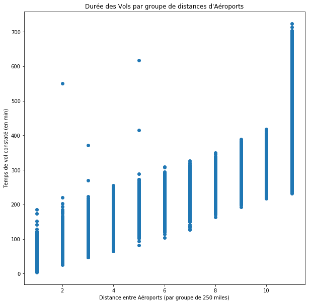

```python
# On regarde le Temps de vol par groupe de distance parcouru
df2 = df[['AIR_TIME', 'DISTANCE_GROUP']]
plt.figure(figsize=(10,10))
plt.scatter(x=df2.DISTANCE_GROUP, y=df2.AIR_TIME)
plt.xlabel('Distance entre Aéroports (par groupe de 250 miles)')
plt.ylabel('Temps de vol constaté (en min)')
plt.title("Durée des Vols par groupe de distances d'Aéroports")
plt.show()
```

> On remarque 5 Outliers bien distants du reste

> Nous allons les supprimer

```python
u1 = ((df.DISTANCE_GROUP<4) & (df.AIR_TIME>250))
u2 = ((df.DISTANCE_GROUP==5) & (df.AIR_TIME>300))
u = df[u1 | u2]
df.drop(labels=u.index, inplace=True)
```

# DEP_DELAY

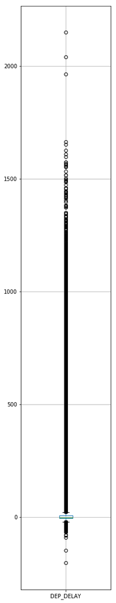

```python
df.boxplot(column=['DEP_DELAY'], figsize=(3, 20))
plt.show()
```

> On remarque des Outliers pour les valeurs de retard de DEPART supérieurs à 1700 et inférieurs à -70

> Nous allons supprimer ces données

```python
df.drop(labels=df[(df.DEP_DELAY>1700) | (df.DEP_DELAY<-70)].index, inplace=True)
```

# ARR_DELAY:

Nous avons des valeurs qui se détachent des autres, au dessus de 1600 min de retard

> Nous les supprimons

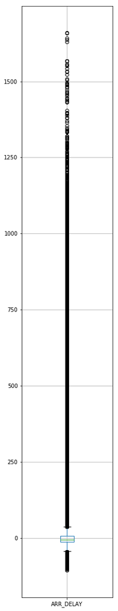

```python
df.boxplot(column=['ARR_DELAY'], figsize=(3, 20))
plt.show()
```

```python
df.drop(labels=df[df.ARR_DELAY>1600].index, inplace=True)
```

# SAUVEGARDE

```python
df.to_csv('datas_total_etape_2.csv', index=False)
AEROPORTS.to_csv('aeroports_nettoyes.csv', index=True)
```

# EXPLORATION DES DONNEES

```python
sum(df.ARR_DELAY> 250), sum(df.ARR_DELAY> 500)
```

```
(21297, 3347)
```

```python
df.ARR_DELAY.describe()
```

```
count    5.440125e+06
mean     3.574663e+00
std      4.190924e+01
min     -1.070000e+02
25%     -1.400000e+01
50%     -6.000000e+00
75%      6.000000e+00
max      1.568000e+03
Name: ARR_DELAY, dtype: float64
```

## La feature ARR_DELAY

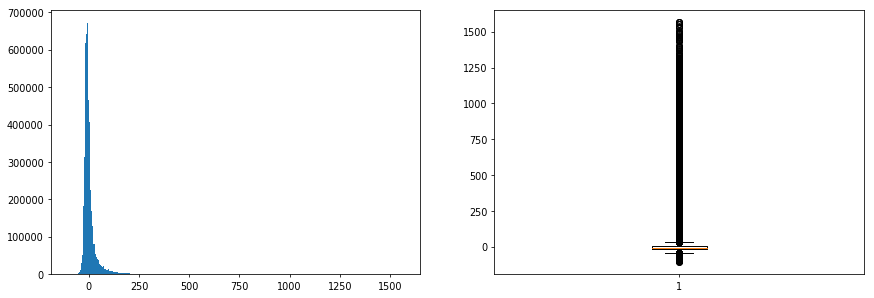

```python
fig = plt.figure(figsize=(15,5), dpi=70)
ax1 = plt.subplot(121)
ax1.hist(df.ARR_DELAY, bins=400)

ax2 = plt.subplot(122)
ax2.boxplot(df.ARR_DELAY)
plt.show()
```

```python
print('La valeur du skeeness empirique est de ', df.ARR_DELAY.skew())
print('La valeur du kurtosis empirique est de ', df.ARR_DELAY.kurtosis())
```

```
La valeur du skeeness empirique est de  7.658516645714223
La valeur du kurtosis empirique est de  123.30787695951504
```

## REMARQUE:

> Le skeeness étant plus grand que 0 : nous avons donc une distribution étalée à droite

> Le kurtosis est plus grand que 0 : la distribution est bien plus étirée à la verticale que la distribution normale

> Les données sont bien (comme on voit sur l'histogramme), très concentrées autour de zéro

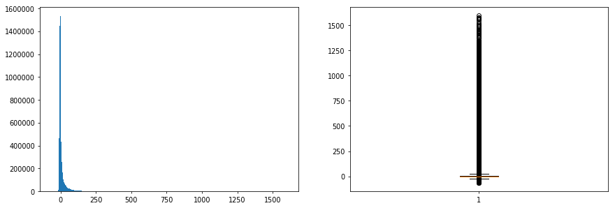

```python
fig = plt.figure(figsize=(15,5), dpi=70)
ax1 = plt.subplot(121)
ax1.hist(df.DEP_DELAY, bins=400)

ax2 = plt.subplot(122)
ax2.boxplot(df.DEP_DELAY)
plt.show()
```

```python
print('La valeur du skeeness empirique est de ', df.DEP_DELAY.skew())
print('La valeur du kurtosis empirique est de ', df.DEP_DELAY.kurtosis())
```

```
La valeur du skeeness empirique est de  8.837002765926863
La valeur du kurtosis empirique est de  151.46482817822806
```

## REMARQUE:

Mêmes constatations que pour ARR_DELAY

> Le skeeness étant plus grand que 0 : nous avons donc une distribution étalée à droite

> Le kurtosis est plus grand que 0 : la distribution est bien plus étirée à la verticale que la distribution normale

> Les données sont bien (comme on voit sur l'histogramme), très concentrées autour de zéro

> On voit d'ailleurs que DEP_DELAY est encore plus étiré vers le haut de ARR_DELAY

## Retard inférieurs à 15 minutes

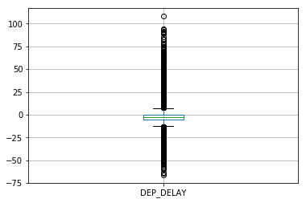

```python
df[df.ARR_DEL15==0].boxplot(column=['DEP_DELAY'])
```

```
array([[<matplotlib.axes._subplots.AxesSubplot object at 0x11b74c748>]],
      dtype=object)
```

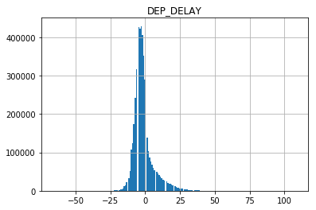

```python
df[df.ARR_DEL15==0].hist(column=['DEP_DELAY'], bins=200)
```

```python
sum((df.ARR_DEL15==0) & (df.DEP_DELAY>50))
```

```
496
```

## ANALYSE DES MOYENNES

> Nous allons représenter les valeurs par leurs moyennes selon un axe de temps donnés (MOIS, JOUR DE LA SEMAINE, JOUR DE L'ANNEE, HEURE DE DEPART).

> Afin de comparer celles-ci à la moyenne observée du retard moyen, nous allons normaliser ces moyennes.

> De plus nous allons faire une regression linéaire entre ces données (en donnant le $R^2$ de ces dernières)

```python
def representation(m_data, nom1, nom2='ARR_DELAY', param1 = 'FL_DATE'):
    #param1 = 'FL_DATE'
    df1 = m_data[[param1,nom1]].groupby([param1]).agg('mean').reset_index()
    df2 = m_data[[param1,nom2]].groupby([param1]).agg('mean').reset_index()
    fig = plt.figure(figsize=(10,10), dpi=70)

    ## 2e Graph
    #### NORMALISATION DES DONNEES
    from sklearn.preprocessing import MinMaxScaler
    minmax1 = MinMaxScaler()
    minmax1.fit(df1[nom1].values.reshape(-1, 1))
    tmp_data = minmax1.transform(df1[nom1].values.reshape(-1, 1))

    minmax2 = MinMaxScaler()
    minmax2.fit(df2[nom2].values.reshape(-1, 1))
    arr_delay = minmax2.transform(df2[nom2].values.reshape(-1, 1))

    #### LES 2 GRAPHIQUES ENSEMBLE
    ax3 = plt.subplot(211)
    ax3.plot(df1[param1], tmp_data,label='Moyenne Normalisée de {}'.format(nom1))
    ax3.plot(df1[param1], arr_delay,label='Moyenne Normalisée de {}'.format(nom2))
    ax3.tick_params(axis='x',labelrotation=90 , labelsize=8.0, pad=2)
    ax3.set_title('Evolution des moyennes normalisées en fonction de  {}'.format(param1))
    ax3.set_xlabel(param1)

    if (df1[param1].nunique()>30):
        ax3.set_xticks(ticks=df1[param1][::1], minor=True)
        ax3.set_xticks(ticks=df1[param1][::10], minor=False)
        plt.gcf().subplots_adjust(wspace = 0, hspace = 0.5)

    else:
        plt.gcf().subplots_adjust(wspace = 0, hspace = 0.3)
        ax3.set_xticks(ticks=df1[param1][::1], minor=True)
        ax3.set_xticks(ticks=df1[param1][::1], minor=False)
    ax3.grid(which = 'minor', alpha = 0.3)
    ax3.grid(which = 'major', alpha = 0.9)
    ax3.legend()

    from sklearn.linear_model import LinearRegression

    lr = LinearRegression()
    lr.fit(tmp_data, arr_delay)
    r_2 = lr.score(tmp_data, arr_delay)
    ax4 = plt.subplot(212)
    ax4.scatter(tmp_data, arr_delay, c='y', s=10.0)
    ax4.plot(tmp_data, lr.predict(tmp_data), c='b')
    ax4.set_xlabel('Moyenne Normalisée de '+nom1+ ' par '+param1)
    ax4.set_ylabel('Moyenne Normalisée de '+nom2+ ' par '+param1)
    ax4.set_title('Régression Linéraire : $R^2$ = {}'.format(str(r_2)))
    plt.show()
```

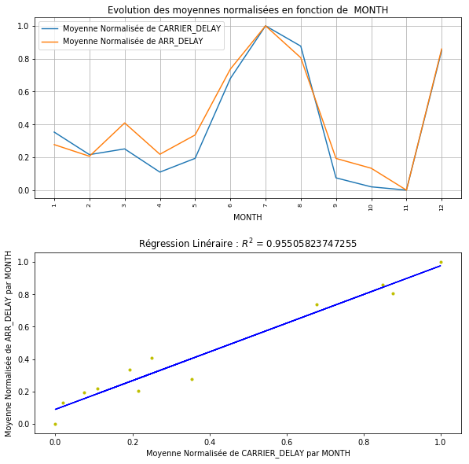

```python
representation(m_data=df, nom1='CARRIER_DELAY', nom2='ARR_DELAY' , param1='MONTH')
```

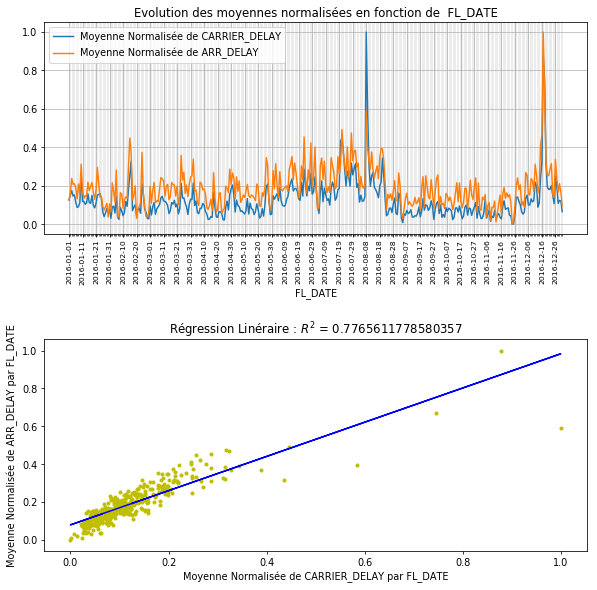

```python
representation(m_data=df, nom1='CARRIER_DELAY', nom2='ARR_DELAY' , param1='FL_DATE')
```

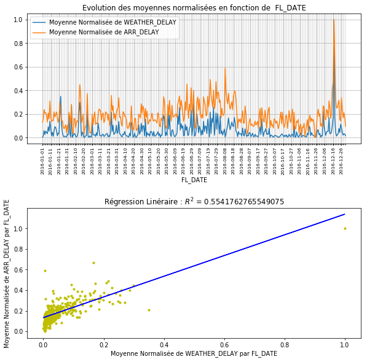

```python
representation(m_data=df, nom1='WEATHER_DELAY', nom2='ARR_DELAY' , param1='FL_DATE')
```

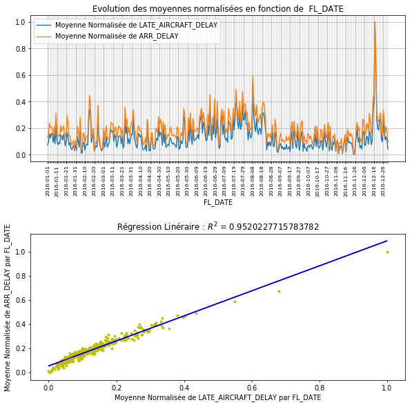

```python
representation(m_data=df, nom1='LATE_AIRCRAFT_DELAY', nom2='ARR_DELAY' , param1='FL_DATE')
```

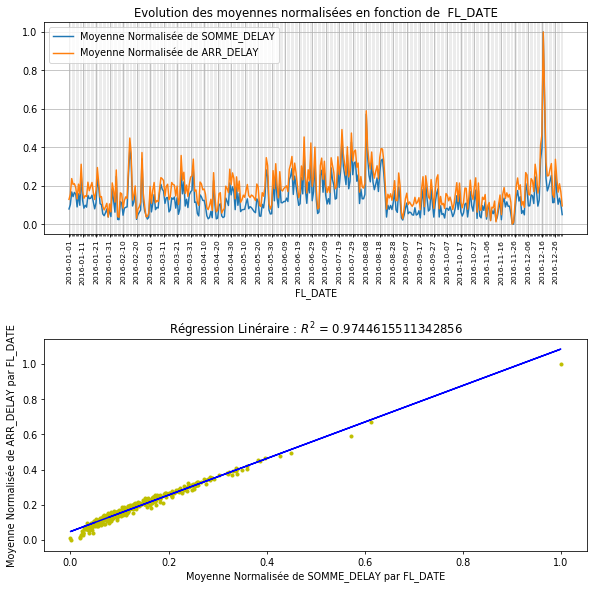

```python
representation(m_data=df, nom1='SOMME_DELAY', nom2='ARR_DELAY' , param1='FL_DATE')
```

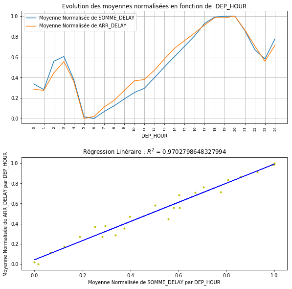

```python
representation(m_data=df, nom1='SOMME_DELAY', nom2='ARR_DELAY' , param1='DEP_HOUR')
```

## Synthèse:

- Les moyennes des données de Délais (liés au Temps, à l'embarquement etc... ) individuellement semblent suivre les mêmes tendances que celles de délai total
- Les délais dépendent des heures, mais aussi des jours et mois de l'année
- Les moyennes de la somme des différents temps de retards observés semblent suivre la même tendance que le délai total

## ARR_DELAY et DEP_DELAY

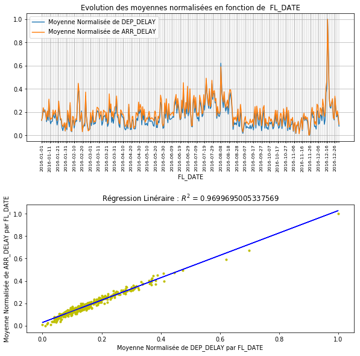

```python
representation(m_data=df, nom1='DEP_DELAY', nom2='ARR_DELAY' , param1='FL_DATE')
```

> Comme nous pouvions nous en douter : le délai total et le délai de Départ sont très liés.

> Le délai au départ a une influence forte sur le délai que l'on retrouve à l'arrivée

## ARR_DELAY et ARR_DEL15

> ARR_DEL15 est une donnée binaire qui donne l'information sur le fait que le retard total est de plus ou moins 15 minutes

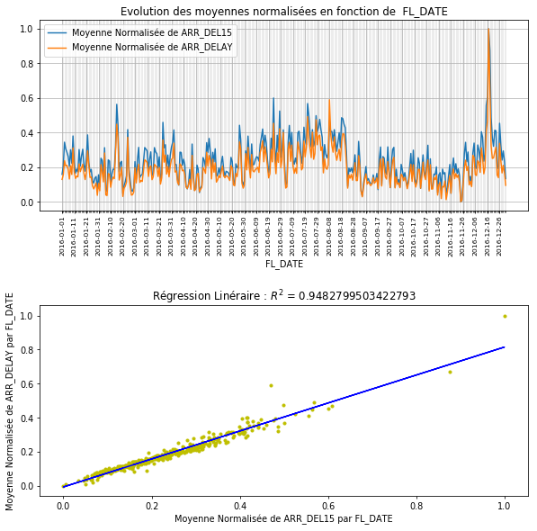

```python
representation(m_data=df, nom1='ARR_DEL15', nom2='ARR_DELAY' , param1='FL_DATE')
```

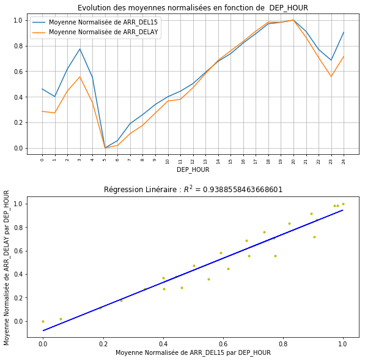

```python
representation(m_data=df, nom1='ARR_DEL15', nom2='ARR_DELAY' , param1='DEP_HOUR')
```

## SYNTHESE:

> On constate que l'information donnant le dépassement (ou non) de 15 minutes à l'arrivée suit de très prés la tendance de la moyenne du retard constaté

> Que ce soit pour chaque jour, comme par heure de Départ moyen dans les journée.

## Les délais par compagnie

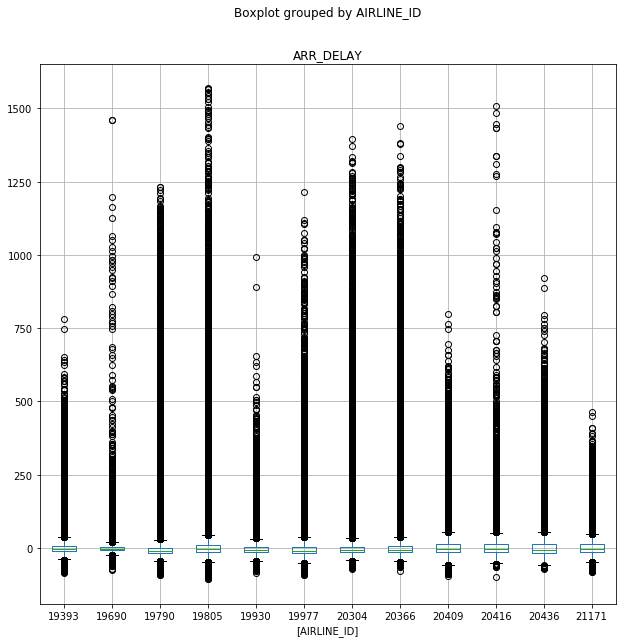

```python
df.boxplot(column=['ARR_DELAY' ], by=['AIRLINE_ID'], figsize=(10,10))
```

## Conclusion:

La répartition des retards par compagnie est très disparate.

> Il est donc souhaitable de travailler individuellement sur chaque compagnie pour obtenir un résultat plus représentatif